# PHS 7045: Advanced Programming

Presentation - Simulation Studies with Modana Package

Eric Anto

## Moderation Analysis with binary outcomes using the Modana package

Moderation analysis essentially involves treatment-by-covariates interactions.

- We employ the nice symmetry property about ratio of odds ratios, which suggests that heterogeneous treatment effects could be equivalently estimated via a role exchange between the outcome and treatment variable in logistic regression models.
- Refined inference on moderating effects can be obtained by rearranging data and combining two models into one via a GEE (generalized estimating equation) approach.
- This approach can be helpful in identifying treatment-by-covariate interactions (a common problem in the search for important moderators).
- We use the `Modana` package to carry out simulation.

## The set-up

- Suppose that the available data, $\mathcal{D} = \left\{(y_i,t_i, x_i): i=1, \ldots, n \right\}$, consist of $n$ IID copies of $(y, t, x)$, where both $y$ and $t$ are 0/1-coded binary variables and $X \in \mathbb{R}^p$ is a $p$-dimensional covariate vector.
- A $y$ value of 1 indicates the occurrence of an event of interest (e.g., death) and a $y$ value of 0 indicates the absence of the event (e.g., survival).
- A treatment assignment variable $t$ has value 1 for participants who are randomized into the treated group and value 0 for the untreated.
- With the covariate vector fixed at $\bf{x}=\bf{a},$. The ratio of the odds in the treated group and the odds in the untreated group is defined as.
  $$\begin{equation}
  \label{OR-Y}
  OR^{(y)}_{\textbf{a}} = \frac{\Pr(y=1\, |\, t=1, \textbf{x}=\textbf{a}) / \Pr(y=0\, |\, t=1, \textbf{x}=\textbf{a})}{ \Pr(y=1\, |\, t=0, \textbf{x}=\textbf{a}) / \Pr(y=0\, |\, t=0, \textbf{x}=\textbf{a})}
  \end{equation}$$
- Ratio of Odds Ratios (ROR)
  - In moderation analysis, one is primarily concerned about differential treatment effects among patients with heterogeneous characteristics.
  - Consider two sets of patients or individuals: one with covariates $\bf{x}= \bf{a}$ and the other with covariates $\bf{x} = \bf{b}$

## The set-up (Cont’d)

- Ratio of Odds Ratios (ROR)
- By definition, ROR compares the treatment efficacy (measured by OR) between the two patient sets, as given by $ROR^{(y)}(\textbf{a}:\textbf{b}) = OR^{(y)}_{\textbf{a}}/ OR^{(y)}_{\textbf{b}}.$
- If we swap the roles of $y$ and $t$, both OR and ROR remain the same.
- Specifically, let $OR^{(t)}_{\textbf{a}}$ denote the odds ratios of being treated for comparing cases ($y=1$) versus controls ($y=0$), while fixing $\textbf{x}=\textbf{a}$, as

$$\begin{equation}
\label{OR-T}
OR^{(t)}_{\textbf{a}} = \frac{\Pr(t=1\, |\, y=1, \textbf{x}=\textbf{a}) / \Pr(t=0\, |\, y=1, \textbf{x}=\textbf{a})}{\Pr(t=1\, |\, y=0, \textbf{x}=\textbf{a}) / \Pr(t=0\, |\, y=0, \textbf{x}=\textbf{a})}.
\end{equation}$$

- Define $ROR^{(t)}(\textbf{a}:\textbf{b}) = OR^{(t)}_{\textbf{a}} / OR^{(t)}_{\textbf{b}}$ to be the ROR compares the OR of being treated between the two patients sets.

## The set-up (Cont’d)

The proposition:

Let $OR^{(y)}_{\textbf{a}},$ $OR^{(t)}_{\textbf{a}}$, $ROR^{(y)}(\textbf{a}:\textbf{b})$ and $ROR^{(t)}(\textbf{a}:\textbf{b})$ be the odds ratios and the ratios of odds ratios as defined above. We have

1. $OR^{(y)}_{\textbf{a}} = OR^{(t)}_{\textbf{a}},~ \forall \, \textbf{a}.$
2. $ROR^{(y)}(\textbf{a}:\textbf{b}) = ROR^{(t)}(\textbf{a}:\textbf{b}),~ \forall \, \textbf{a}, \textbf{b}.$

## Implications on Logistic Regression Models

Suppose that one is interested in the main effect of treatment $t$ and fits the following two logistic modes by swapping the roles of $y$ and $t$

$$\begin{equation}
\left\{
\begin{array}{lcl}
\mbox{logit} \Pr(y=1 \, | \, t, \textbf{x}) &=& \beta_0 + \beta_1 t + \textbf{x}^T\bf{\beta}_2 + t \cdot \text{x}^T \bf{\gamma} \\
\mbox{logit} \Pr(t=1 \, | \, y, \textbf{x}) &=& \beta'_0 + \beta'_1 y + \bf{x}^T \bf{\beta}'_2 + y \cdot \textbf{x}^T \bf{\gamma}'
\end{array}
\right.
\label{model-main}
\end{equation}$$

- Our proposition `(i)` implies that $\beta_1 = \beta'_1,$ since $\exp(\beta_1) = OR^{(y)}_{\textbf{a}}$ and $\exp(\beta'_1) = OR^{(t)}_{\textbf{a}}$ with any fixed $\textbf{x} = \textbf{a}.$
- By Proposition (ii), $\exp(\gamma_j) = ROR^{(y)}(\textbf{a}: \textbf{b})$ and $\exp(\gamma'_j) = ROR^{(t)}(\textbf{a}: \textbf{b}).$. Thus, $\gamma_j = \gamma'_j$ and hence $\bf{\gamma} =\bf{\gamma}'.$

## Refined Estimation of Moderating Effects

We can be further the above models reduced to

$$\begin{equation}
\left\{
\begin{array}{lcl}
\mbox{logit} \Pr(y=1 \, | \, t, \textbf{x}) &=& \beta_0 + \beta_1 t + \textbf{x}^T\bf{\beta}_2 + t \cdot \text{x}^T \bf{\gamma} \\
\mbox{logit} \Pr(t=1 \, | \, y, \textbf{x}) &=& \beta'_0 + \beta_1 y + \bf{x}^T \bf{\beta}'_2 + y \cdot \textbf{x}^T \bf{\gamma}
\end{array}
\right.
\label{model-main1}
\end{equation}$$

- To come up with a better estimator of $\bf{\gamma}$ in moderation analysis,
  - we estimate the parameters by pooling together the likelihood or quasi-likelihood functions of the two models as if they were built on independent data.
  - The main idea of this computing trick is to rearrange data into a format for clustered or longitudinal data
  - Define $y'_{ij} = y_i$ if $j=1$ and $y'_{ij} = t_i$ if $j=2$; define $t'_{ij} = t_i$ if $j=1$ and $t'_{ij} = y_i$ if $j=2$; let $z_{ij} =j-1$ and $\textbf{x}_{ij}=\textbf{x}_i$ for $j=1, 2$ and $i=1, \ldots , n.$
  - We arrive at a clustered data set $\mathcal{D}'=\{(y'_{ij}, t'_{ij}, z_{ij}, \textbf{x}_{ij}): i=1, \ldots, n \,\,\text{and} \,\, j=1, 2\}$, which is obtained by swapping the response and treatment columns in the original data $\mathcal{D}$ and then stacking it on top of $\mathcal{D}$.
  - The dummy variable $z$ is introduced to distinguish the two models.

## Refined Estimation of Moderating Effects (cont’d)

Consider the following marginal model for $y'_{ij}$

$$\begin{eqnarray}
\label{model-marginal}
\log \frac{\pi_{ij}}{1- \pi_{ij}} & = & \theta_0 + \theta_1 z_{ij} +
\theta_2 t'_{ij} + \bf{\theta}_3^T \textbf{x}_{ij} + z_{ij} \cdot \bf{\theta}_4^T \textbf{x}_{ij} + t'_{ij}\cdot \bf{\theta}_5^T \textbf{x}_{ij},
\end{eqnarray}$$

where $\pi_{ij} = E(y'_{ij} \,|\, t'_{ij}, z_{ij}, \textbf{x}_{ij}) = \Pr(y'_{ij}=1\,|\, t'_{ij}, z_{ij}, \textbf{x}_{ij})$.

- Introduce $\textbf{x}'_{ij}=(1, z_{ij}, t'_{ij}, \textbf{x}_i, z_{ij} \textbf{x}_i^T, t'_{ij} \textbf{x}_i^T)^T$ to rewrite the above model as $\pi_{ij} = \pi( \bf{\theta}^T \textbf{x}'_{ij})$, where the expit or logistic function $\pi(x) = \exp(x) / \{ 1 + \exp(x)\}$ is the inverse function of the logit function.
- By reparameterization of the above model:
  - $\theta_0 = \beta_0$, $\theta_1 = \beta'_0- \beta_0$, $\theta_2 = \beta_1$, $\bf{\theta}_3 = \bf{\beta}_2$, $\bf{\theta}_4 = \bf{\beta}'_2 - \bf{\beta}_2$
  - Importantly, $\bf{\theta}_5 = \bf{\gamma}.$
  - Parameters $\bf{\theta} = (\theta_0, \theta_1, \ldots, \bf{\theta}_5^T)^T$ in the marginal model above can be conveniently estimated with the GEE approach.

## Numerical Results

- Data are generated from the model

$$\begin{equation}
\label{model-simulation}
\log \frac{\Pr(y_i=1 \, | \, t_i, \textbf{x}_i)}{\Pr(y_i=0 \, | \, t_i, \textbf{x}_i)} =
\beta_0 + \beta_1 t_i + \bf{x}_i^T \bf{\beta}_2 + t_i \cdot \textbf{x}_i^T \bf{\gamma},
\end{equation}$$

- Main Effect Estimation (Based on Proposition `(i)`):
  - We set $\bf{\gamma} = \bf{0}$ so that the model is additive; in addition, $\beta_0= -1$, $\beta_1 = 0.5,$ $\bf{\beta}_2 = (0.5, -1, 1)^T.$ We are interested in estimating $\beta_1$.
- Moderating Effect Estimation (Based on Proposition `(ii)`):
  $$\begin{eqnarray}
  \log \frac{\Pr(y=1 \, | \, t, \textbf{x})}{\Pr(y=0 \, | \, t, \textbf{x})} = -1 + 0.5 \, t + 0.5 \, x_1 - \frac{b}{2} x_2 + x_3 + btx_1,
  \label{model-studyII}
  \end{eqnarray}$$
  - where $x_1$ is the only effect-moderator of the treatment with slope $\gamma =b$ is of interest. The value of $b$ varies from no to weak and strong moderating effects (e.g., $\{0.0, 0.5, 1.0, \ldots, 5\}$).

## Simulation Results

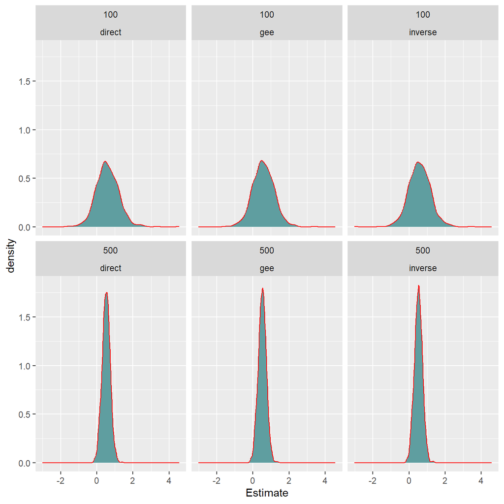

Empirical densities from simulation results for assessing the main effect of treatment

| method | N | Means | SD | Average SE |
| --- | --- | --- | --- | --- |
| direct | 100 | 0.5858648 | 0.6286471 | 0.5572460 |
| direct | 500 | 0.5156508 | 0.2232569 | 0.2194218 |
| gee | 100 | 0.5736793 | 0.5906271 | 0.5320513 |
| gee | 500 | 0.5153380 | 0.2216451 | 0.2176317 |
| inverse | 100 | 0.5766993 | 0.6073516 | 0.5466016 |
| inverse | 500 | 0.5158959 | 0.2218553 | 0.2180373 |

## Simulation Results (cont’d)

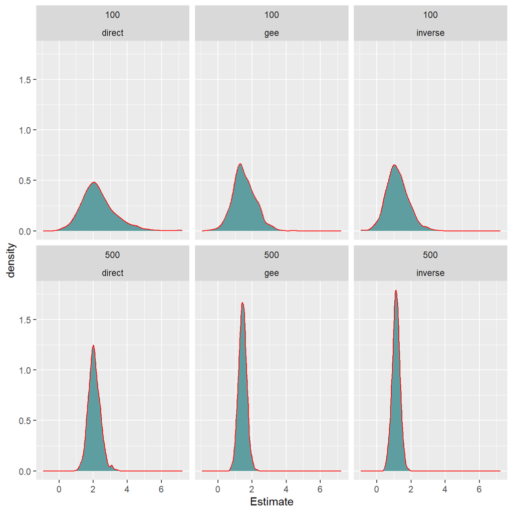

Empirical densities from simulation results for assessing the moderating effect

[output not shown]

## Results

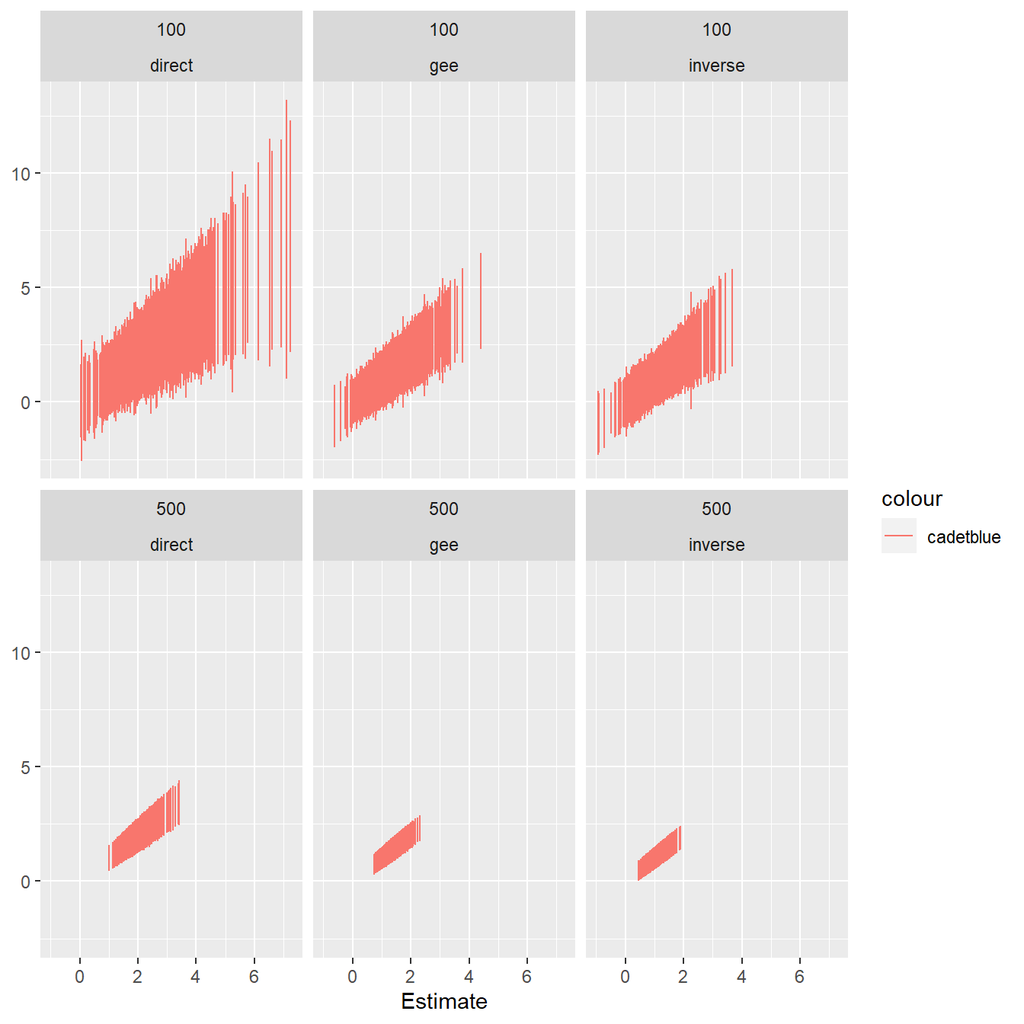

Empirical confidence interval from simulation results for assessing the moderating effect